# Exploratory Subgroup Identification with ForestSearch

- Show All Code
- Hide All Code
- View Source

German Breast Cancer Study Group (GBSG) Analysis

Author

Larry F. León

Published

June 14, 2026

# 1 Analysis Configuration

All tunable parameters for this vignette are defined here in one place, so that GRF, ForestSearch, frontier-CI, bootstrap, and cross-validation settings are not scattered through the document.

## 1.1 Run-time flags

```r
run_cv_kfold <- TRUE   # K-fold CV (forestsearch_tenfold + summarize_cv_results)
run_cv_oob   <- TRUE   # Leave-one-out CV (forestsearch_Kfold)
# K-fold CV: number of repeated 10-fold partitions
# Use Ksims >= 50 for production
Ksims <- 50
```

## 1.2 Parallel processing & iteration counts

```r
# Detect available cores
n_cores_total <- parallel::detectCores()
n_cores       <- max(1L, floor(0.95 * parallel::detectCores(logical = FALSE)))
cat("Using", n_cores, "of", n_cores_total, "total cores for parallel processing")
```

```
#> Using 30 of 32 total cores for parallel processing
```

```r
# Bootstrap iterations: 500-2000 for production; reduced here for vignette
NB <- 1000
```

## 1.3 GRF parameters

Used by the preliminary GRF analysis. Note that `dmin.grf` and `frac.tau` differ between the GRF standalone analysis and the GRF candidate-selection inside ForestSearch (see `fs_params`).

```r
grf_params <- list(
  maxdepth                  = 2L,
  n.min                     = 60L,
  dmin.grf                  = 12L,
  frac.tau                  = 0.60,
  details                   = TRUE,
  return_selected_cuts_only = FALSE
)
```

## 1.4 ForestSearch parameters

```r
fs_params <- list(
  # Threshold parameters (per León et al. 2024)
  hr.threshold           = 1.25,
  hr.consistency         = 1.0,
  pconsistency.threshold = 0.90,
  stop_threshold         = 0.95,
  # Search configuration
  sg_focus               = "hr",
  # For hr selection_rule:= "neighborhood"
  # selection_rule         = "neighborhood",
  max_subgroups_search   = 20L,
  use_twostage           = TRUE,
  # Factor selection
  use_grf                   = TRUE,
  dmin.grf                  = 4L,
  frac.tau                  = 0.80,
  return_selected_cuts_only = TRUE,
  use_lasso                 = TRUE,
  cut_type                  = "default",
  conf.cont_jcuts           = list(er = 10, pgr = 10),
  # Subgroup constraints
  maxk   = 2L,
  n.min  = 60L,
  d0.min = 10L,
  d1.min = 10L,
    # Consistency evaluation
  fs.splits = 1000L,
  # Output options
  show_candidate_summary = TRUE,
  details           = TRUE,
  plot.sg           = TRUE
)
```

## 1.5 Frontier-CI and table-display parameters

Used by `compute_frontier_cis()`, `plot_pareto_frontier()`, and `pareto_frontier_table()` in the Pareto frontier diagnostic.

```r
frontier_params <- list(
  n_splits      = 1000L,
  seed          = 1L,
  xlim          = c(1.25, 3.0),
  digits_effect = 2L,
  digits_pcons  = 2L,
  digits_ci     = 2L
)
```

## 1.6 CV-result placeholders

Initialised to `NULL` so downstream references (forest plot, timing summary) work whether or not the CV steps actually run.

```r
fs_kfold       <- NULL
fs_OOB         <- NULL
cv_diag        <- NULL
metrics_tables <- NULL
tables         <- NULL
timings$kfold  <- NA_real_
timings$oob    <- NA_real_
```

# 2 Introduction

This vignette demonstrates the **ForestSearch** methodology for exploratory subgroup identification in survival analysis, as described in León et al. (2024) *Statistics in Medicine*.

## 2.1 Motivation

In clinical trials, particularly oncology, subgroup analyses are essential for:

- Evaluating treatment effect consistency across patient populations
- Identifying subgroups where treatment may be detrimental (harm)
- Characterizing subgroups with enhanced benefit
- Informing regulatory decisions and clinical practice

While prespecified subgroups provide stronger evidence, important subgroups based on patient characteristics may not be anticipated. ForestSearch provides a principled approach to **exploratory** subgroup identification with proper statistical inference.

## 2.2 Methodology Overview

ForestSearch identifies subgroups through:

1. **Candidate factor selection**: Using LASSO and/or Generalized Random Forests (GRF)
2. **Exhaustive subgroup search**: Evaluating all combinations up to `maxk` factors
3. **Consistency-based selection**: Applying splitting consistency criteria
4. **Bootstrap bias correction**: Adjusting for selection-induced optimism
5. **Cross-validation**: Assessing algorithm stability

The key innovation is the **splitting consistency criterion**: a subgroup is considered “consistent with harm” if, when randomly split 50/50 many times, both halves consistently show hazard ratios ≥ 1.0 (for example if 1.0 represents a meaningful “harm threshold”).

# 3 Setup

## 3.1 Load Required Packages

```r
library(forestsearch)
library(survival)
library(data.table)
library(ggplot2)
library(gt)
library(grf)
library(policytree)
library(doFuture)
# Optional packages for enhanced output
library(patchwork)
library(weightedsurv)

# Set ggplot theme
theme_set(theme_minimal(base_size = 12))
```

# 4 Data: German Breast Cancer Study Group Trial

## 4.1 Study Background

The GBSG trial evaluated hormonal treatment (tamoxifen) versus chemotherapy in node-positive breast cancer patients. Key characteristics:

- **Sample size**: N = 686
- **Outcome**: Recurrence-free survival time
- **Censoring rate**: ~56%
- **Treatment**: Hormonal therapy (tamoxifen) vs. chemotherapy

## 4.2 Data Preparation

```r
# Load GBSG data (included in forestsearch package)
df.analysis <- gbsg

# Prepare analysis variables
df.analysis <- within(df.analysis, {
  id <- seq_len(nrow(df.analysis))
  time_months <- rfstime / 30.4375
  grade3 <- ifelse(grade == "3", 1, 0)
  treat <- hormon
})

# Define variable roles
confounders.name <- c("age", "meno", "size", "grade3", "nodes", "pgr", "er")
outcome.name <- "time_months"
event.name <- "status"
id.name <- "id"
treat.name <- "hormon"

# Display data structure
cat("Sample size:", nrow(df.analysis), "\n")
```

```
#> Sample size: 686
```

```r
cat("Events:", sum(df.analysis[[event.name]]),
    sprintf("(%.1f%%)\n", 100 * mean(df.analysis[[event.name]])))
```

```
#> Events: 299 (43.6%)
```

```r
cat("Baseline factors:", paste(confounders.name, collapse = ", "), "\n")
```

```
#> Baseline factors: age, meno, size, grade3, nodes, pgr, er
```

## 4.3 Baseline Characteristics

```r
create_summary_table(
  data = df.analysis,
  treat_var = treat.name,
  table_title = "GBSG Baseline Characteristics by Treatment Arm",
  vars_continuous = c("age", "nodes", "size", "er", "pgr"),
  vars_categorical = c("grade", "meno"),
  font_size = 12
)
```

GBSG Baseline Characteristics by Treatment Arm

| Characteristic |  | Control (n=440) | Treatment (n=246) | P-value<sup>1</sup> | SMD<sup>2</sup> |
| --- | --- | --- | --- | --- | --- |
| age | Mean (SD) | 51.1 (10.0) | 56.6 (9.4) | <0.001 | 0.57 |
| nodes | Mean (SD) | 4.9 (5.6) | 5.1 (5.3) | 0.665 | 0.03 |
| size | Mean (SD) | 29.6 (14.4) | 28.8 (14.1) | 0.470 | 0.06 |
| er | Mean (SD) | 79.7 (124.2) | 125.8 (191.1) | <0.001 | 0.30 |
| pgr | Mean (SD) | 102.0 (170.0) | 124.3 (249.7) | 0.213 | 0.11 |
| grade |  |  |  | 0.273 | 0.06 |
|  | 1 | 48 (10.9%) | 33 (13.4%) |  |  |
|  | 2 | 281 (63.9%) | 163 (66.3%) |  |  |
|  | 3 | 111 (25.2%) | 50 (20.3%) |  |  |
| meno |  | 209 (47.5%) | 187 (76.0%) | <0.001 | 0.61 |

<sup>1</sup> P-values: t-test for continuous, chi-square/Fisher's exact for categorical/binary variables  
<sup>2</sup> SMD = Standardized mean difference (Cohen's d for continuous, Cramer's V for categorical)

## 4.4 Kaplan-Meier Analysis (ITT Population)

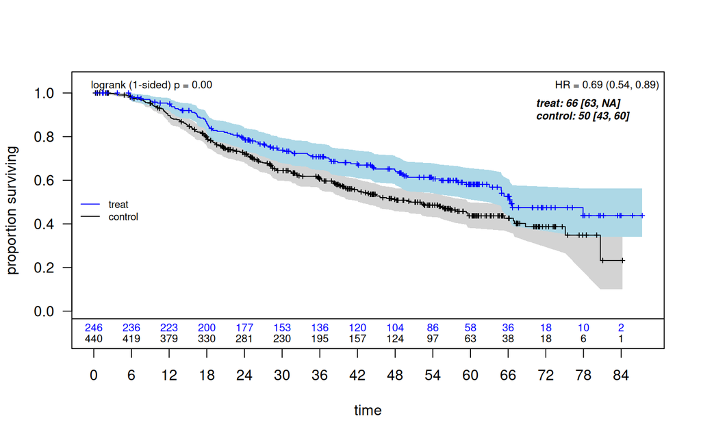

```r
# Prepare counting process data for KM plot
dfcount <- df_counting(
  df = df.analysis,
  by.risk = 6,
  tte.name = outcome.name,
  event.name = event.name,
  treat.name = treat.name
)

# Plot with confidence intervals and log-rank test
plot_weighted_km(
  dfcount,
  conf.int = TRUE,
  show.logrank = TRUE,
  ymax = 1.05,
  xmed.fraction = 0.775,
  ymed.offset = 0.125
)
```

The ITT Cox hazard ratio estimate is approximately 0.69 (95% CI: 0.54, 0.89), suggesting an overall benefit for hormonal therapy.

# 5 Preliminary Analysis: Generalized Random Forests

Before running ForestSearch, we can use GRF to explore potential treatment effect heterogeneity and identify candidate factors.

```r
t0 <- proc.time()

# Fixed args (data + names) come from the analysis context; tunable
# parameters come from grf_params in the Analysis Configuration.
grf_est <- do.call(grf.subg.harm.survival, c(
  list(
    data             = df.analysis,
    confounders.name = confounders.name,
    outcome.name     = outcome.name,
    event.name       = event.name,
    id.name          = id.name,
    treat.name       = treat.name
  ),
  grf_params
))
```

```
#> tau, maxdepth = 46.75811 2
#>    leaf.node control.mean control.size control.se depth
#> 1          2         6.49        82.00       3.34     1
#> 2          3        -4.10       604.00       1.06     1
#> 11         4        -7.90       112.00       2.81     2
#> 21         5         3.86       177.00       1.87     2
#> 4          7        -5.89       356.00       1.33     2
#>
#> Selected subgroup:
#>   leaf.node control.mean control.size control.se depth
#> 1         2         6.49        82.00       3.34     1
#>
#> GRF subgroup found
#> Terminating node at max.diff (sg.harm.id):
#> [1] "er <= 0"
#>
#> All splits (from all trees):
#> [1] "er <= 0"   "age <= 50" "age <= 43"
```

```r
timings$grf <- (proc.time() - t0)["elapsed"]
```

```r
# Display policy trees
# leaf1 = recommend control, leaf2 = recommend treatment
oldpar <- par(mfrow = c(1, 2))
plot(grf_est$tree1, leaf.labels = c("Control", "Treat"), main = "Depth 1")
```

[interactive chart not shown]

```r
plot(grf_est$tree2, leaf.labels = c("Control", "Treat"), main = "Depth 2")
```

[interactive chart not shown]

```r
par(oldpar)
```

GRF identifies estrogen receptor status (ER) as a key factor, with ER ≤ 0 suggesting potential harm from hormonal therapy.

# 6 ForestSearch Analysis

## 6.1 Running ForestSearch

ForestSearch performs an exhaustive search over candidate subgroup combinations with up to `maxk` factors. Key parameters:

[output not shown]

**Selection criteria (`sg_focus`)**

- `"hr"` – highest consistency, then largest effect.
- `"minSG"` – smallest passing subgroup, ties broken by consistency.
- `"hrMaxSG"` – among candidates whose effect is within `effect_neighborhood` (default 10%) of the maximum, pick the *largest* sample size.
- `"hrMinSG"` – among candidates within `effect_neighborhood` of the maximum effect, pick the *smallest* sample size.

`"hrMaxSG"` and `"hrMinSG"` use a *lexicographic-with-tolerance* rule: effect size is primary, but a small relative loss in effect is accepted to optimize sample size. Setting `effect_neighborhood = 0` reduces these to a strict max-effect filter. For GLM ratio measures (OR, IRR), the neighborhood test is applied on the natural scale.

```
#>
#> [forestsearch] Subgroup Identification Configuration
#>   Outcome type:   survival (Cox PH)
#>   Effect measure: HR (hazard ratio)
#>   Scale:          log (ratio)
#>
#>   Screening:      HR >= 1.25  (log: 0.2231)
#>   Consistency:    HR >= 1.00  (log: 0.0000)
#>   Consistency rate threshold: 90%
#>
#>   Interpretation:
#>     Candidates: subgroup hazard ratio >= 1.25
#>     Splits:     each split HR >= 1.00
```

```
#>   Search Alignment Diagnostic
```

```
#>
#>   Outcome:    time_months (survival)
```

```
#>   Treatment:  hormon
```

```
#>   Measure:    Hazard Ratio (HR)
```

```
#>
#>   ForestSearch searches for:
#>     Subgroups where hormon increases the event hazard
#>     (HR >= threshold in the candidate subgroup)
```

```
#>
#>   Thresholds:
#>     Screening: HR >= 1.250 in the candidate subgroup
#>     Consistency: HR >= 1.000 in each bootstrap split
```

```
#>
#>   Variable screening:
```

```
#>     LASSO: LASSO screening uses glmnet with family = "Cox (coxnet)".
#>     Variables with non-zero coefficients are retained.
```

```
#>     GRF:   causal_survival_forest() estimates treatment effect on
#>     survival probability. Positive CATE = treatment increases
#>     survival = treatment HELPS (events assumed adverse).
```

```
#>
#>   No alignment concerns detected.
```

```
#> J-quantile cuts: er (J=10), pgr (J=10)
#> GRF subgroup: er <= 0
#> GRF cuts identified: 1
#>   Cuts: er <= 0
#> Cox-LASSO selected: 4 of 7 candidate factors
#>   Omitted: age, meno, er
#> Candidate factors: 29
#>  [1] "er <= 0"    "er <= 3"    "er <= 9"    "er <= 17"   "er <= 30"
#>  [6] "er <= 44"   "er <= 70"   "er <= 100"  "er <= 174"  "er <= 294"
#> [11] "pgr <= 0"   "pgr <= 2"   "pgr <= 8"   "pgr <= 16"  "pgr <= 26"
#> [16] "pgr <= 45"  "pgr <= 77"  "pgr <= 114" "pgr <= 184" "pgr <= 337"
#> [21] "size <= 29" "size <= 25" "size <= 20" "size <= 35" "nodes <= 5"
#> [26] "nodes <= 3" "nodes <= 1" "nodes <= 7" "grade3"
#> Number of possible configurations (<= maxk): maxk = 2 , # combinations = 1711
#> Per-arm events criteria: control >= 10, treatment >= 10
#> Sample size criteria: n >= 60
#> Subgroup search completed in 0.06 minutes
#>
#> --- Filtering Summary ---
#>   Combinations evaluated: 1711
#>   Passed variance check: 1577
#>   Passed prevalence (>= 0.025 ): 1577
#>   Passed redundancy check: 1458
#>   Passed events counts (d0>= 10, d1>= 10): 1086
#>   Passed sample size (n>= 60 ): 1056
#>   Cox model fit successfully: 1056
#>   Passed effect threshold (effect >= 1.2500): 38
#> -------------------------
#>
#> Found 38 subgroup candidate(s)
#> # of candidate subgroups (meeting all criteria) = 38
#> # of unique initial candidates: 38
#> # Restricting to top stop_Kgroups = 20
#> # of candidates to evaluate: 20
#> # Early stop threshold: 0.95
#>
#> ==============================================================================================================
#> CANDIDATE EVALUATION PREVIEW (pre-consistency) (sg_focus = "hr", selection_rule = "neighborhood")
#> ==============================================================================================================
#> Rank  HR      N      E     K    OF  Subgroup
```

[output cut: 10 more lines]

```
#>   10   1.678     63    38    2  -   {size <= 35} & {pgr <= 0}
#>   11   1.666     79    44    2  -   {grade3} & {pgr <= 8}
#>   12   1.626     66    38    2  -   {er <= 3} & {pgr <= 0}
#>   13   1.625     74    44    2  -   {pgr <= 0} & {er <= 17}
#>   14   1.573     75    45    2  -   {pgr <= 0} & {er <= 30}
#>   15   1.481     65    32    2  -   !{er <= 100} & {pgr <= 77}
#>   16   1.474     81    31    2  -   !{er <= 174} & !{nodes <= 1}
#>   17   1.469    104    56    2  *   {grade3} & {pgr <= 16}
#>   18   1.417     97    57    2  -   {pgr <= 2} & {er <= 9}
#>   19   1.399     62    36    2  -   {grade3} & {er <= 3}
#>   20   1.394     78    47    2  -   !{size <= 29} & {er <= 9}
#> --------------------------------------------------------------------------------------------------------------
#> To evaluate: 20   On frontier: 4
#> Legend: OF = on Pareto frontier.
#> ==============================================================================================================
```

```
#> Parallel plan: multisession with 30 workers.
```

```
#> Parallel config: workers = 30 , batch_size = 1
#> Batch 1 / 20 : candidates 1 - 1
#>
#> ==================================================
#> EARLY STOP TRIGGERED (batch 1 )
#>   Candidate: 1 of 20
#>   Pcons: 0.99 >= 0.95
#> ==================================================
#>
#> Evaluated 1 of 20 candidates (early stop)
#> 1 subgroups passed consistency threshold
```

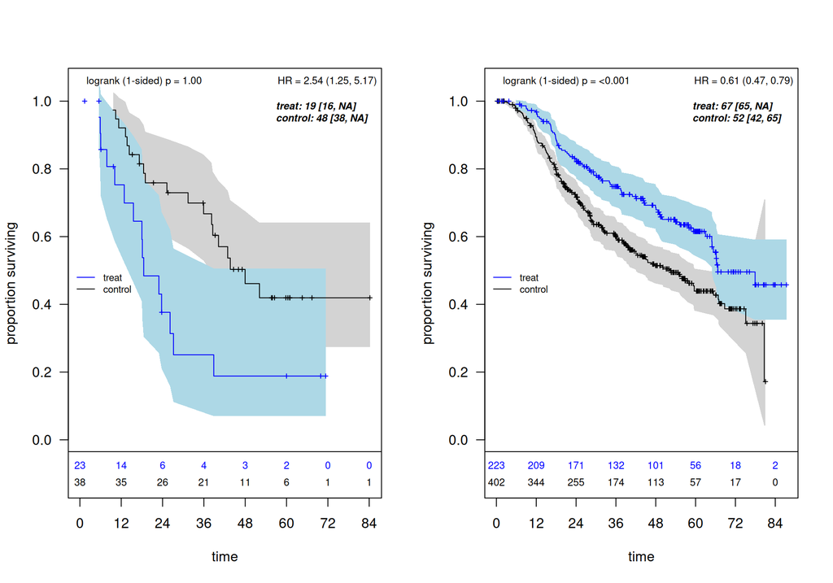

```
#> *** Subgroup found: {er <= 0} {size <= 35}
#> % consistency criteria met= 0.99
#> SG focus = hr
#>
#> ==============================================================================================================
#> CANDIDATE EVALUATION SUMMARY  (sg_focus = "hr", selection_rule = "neighborhood")
#> ==============================================================================================================
#> Rank  HR      N      E     K    P      OF  S  Subgroup
#> --------------------------------------------------------------------------------------------------------------
#>    1   2.537     61    34    2  0.990  *   *  {er <= 0} & {size <= 35}
#> --------------------------------------------------------------------------------------------------------------
#> Evaluated: 1   Passed: 1   On frontier: 1   Selected: m=1
#> Legend: P = Pcons (consistency probability); OF = on Pareto frontier; S = selected.
#> ==============================================================================================================
#>
#> Seconds and minutes forestsearch overall = 6.496 0.1083
#> Consistency algorithm used: twostage
#> Subgroup identified: {er <= 0} & {size <= 35}
```

```r
t0 <- proc.time()

# Fixed args (data + names) come from the analysis context.  All tunable
# thresholds, search settings, and selection options come from fs_params
# in the Analysis Configuration.  parallel_args depends on n_cores so it
# is built here rather than stored in fs_params.
fs <- do.call(forestsearch, c(
  list(
    df.analysis      = df.analysis,
    confounders.name = confounders.name,
    outcome.name     = outcome.name,
    treat.name       = treat.name,
    event.name       = event.name,
    id.name          = id.name,
    parallel_args    = list(
      plan         = "multisession",
      workers      = n_cores,
      show_message = TRUE
    )
  ),
  fs_params
))
```

```r
plan("sequential")
timings$forestsearch <- (proc.time() - t0)["elapsed"]

cat("\nForestSearch completed in",
    round(timings$forestsearch, 1), "seconds\n")
```

```
#>
#> ForestSearch completed in 6.5 seconds
```

## 6.2 ForestSearch Results

### 6.2.1 Identified Subgroups

```r
# Generate results tables
res_tabs <- sg_tables(fs, ndecimals = 3, which_df = "est")

# Display top subgroups meeting criteria
res_tabs$sg10_out
```

**Identified Subgroups**

Two-factor subgroups (maxk=2)

| Factor 1 | Factor 2 | N | Events | E<sub>1</sub> | HR | P<sub>cons</sub> |
| --- | --- | --- | --- | --- | --- | --- |
| {er <= 0} | {size <= 35} | 61 | 34 | 15 | 2.537 | 0.990 |

**Search Configuration:** Single-factor candidates (L) = 58; Maximum combinations evaluated = 1,711; Search depth (maxk) = 2  
**Search Results:** Candidate subgroups found = 38; Maximum HR estimate = 2.54  
**Note:** E<sub>1</sub> = events in treatment arm; P<sub>cons</sub> = consistency proportion

### 6.2.2 Treatment Effect Estimates

```r
# ITT and subgroup estimates
res_tabs$tab_estimates
```

**Treatment Effect Estimates**

Training data estimates

| Subgroup | n | n1 | events | m1 | m0 | RMST | HR (95% CI) |
| --- | --- | --- | --- | --- | --- | --- | --- |
| ITT | 686 (100.0%) | 246 (35.9%) | 299 (43.6%) | 66.3 | 50.2 | 7.8 | 0.69 (0.54, 0.89) |
| Questionable<sup>1</sup> | 61 (8.9%) | 23 (37.7%) | 34 (55.7%) | 18.5 | 48 | -19 | 2.54 (1.25, 5.17) |
| Recommend | 625 (91.1%) | 223 (35.7%) | 265 (42.4%) | 66.7 | 52.2 | 9.6 | 0.61 (0.47, 0.79) |

<sup>1</sup> **Identified subgroup:** {er <= 0} & {size <= 35}

### 6.2.3 Identified Subgroup Definition

```r
cat("Identified subgroup (H):", paste(fs$sg.harm, collapse = " & "), "\n")
```

```
#> Identified subgroup (H): {er <= 0} & {size <= 35}
```

```r
cat("Subgroup size:", sum(fs$df.est$treat.recommend == 0),
    sprintf("(%.1f%% of ITT)\n",
            100 * mean(fs$df.est$treat.recommend == 0)))
```

```
#> Subgroup size: 61 (8.9% of ITT)
```

### 6.2.4 Selection Diagnostic: Pareto Frontier

Beyond the single subgroup chosen by `sg_focus`, it is often informative to inspect the *Pareto frontier* on (effect, N) – the set of candidate subgroups that are not dominated on both axes simultaneously. A candidate is dominated when another candidate has at least as large an effect *and* at least as large a sample size, with at least one strict inequality. The frontier is a post-hoc diagnostic that lists genuine trade-off alternatives to the selected subgroup; it does **not** affect selection.

For `"hrMinSG"` the selected subgroup may not appear on the frontier – that focus deliberately prefers small subgroups, which can be N-dominated by their larger neighbors.

```
#> `geom_path()`: Each group consists of only one observation.
#> ℹ Do you need to adjust the group aesthetic?
```

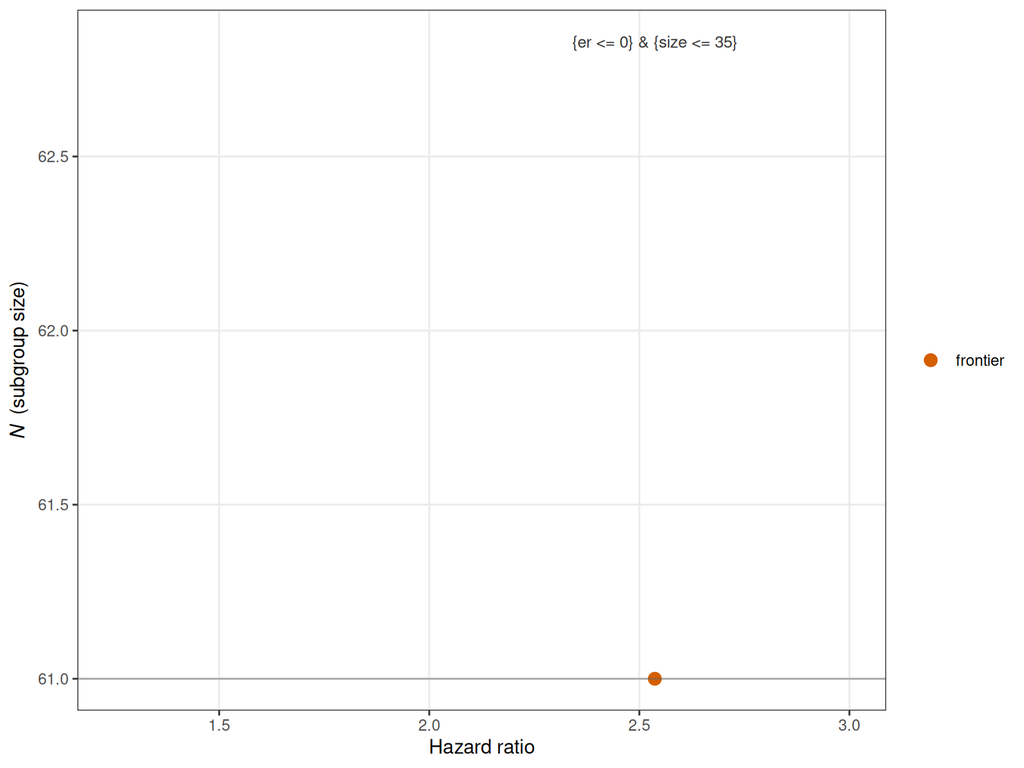

```r
# Formatted gt table; selected subgroup is highlighted and marked with ★.
# Works uniformly for survival (HR) and GLM (OR, RR, IRR, RD, IRD, MD)
# outcomes -- effect column label and scale derived from fs$effect_measure.

# 1. Compute the CIs once (this is the expensive step, ~1-3 min on GBSG).
#    Parameters come from frontier_params in the Analysis Configuration.
ci_tab <- compute_frontier_cis(
  fs,
  n_splits = frontier_params$n_splits,
  seed     = frontier_params$seed
)

# 2. Plot, with split-derived CI bars overlaid; same intervals as the table.
p <- plot_pareto_frontier(
  fs,
  ci_table  = ci_tab,
  show_band = TRUE,
  xlim      = frontier_params$xlim
)
print(p)
```

```r
# 3. Render the table. Pass the same ci_tab so the table and plot
#    show identical intervals.
pareto_frontier_table(
  fs,
  ci_table      = ci_tab,
  digits_effect = frontier_params$digits_effect,
  digits_pcons  = frontier_params$digits_pcons,
  digits_ci     = frontier_params$digits_ci,
  include_dominated= TRUE
)
```

Pareto frontier on (HR, N)

1 non-dominated candidate(s) | sg_focus = 'hr' | HR shown on natural scale | diagnostic only

| S<sup>1,2</sup> | M.1 | M.2 | N | E | HR | P<sup>3</sup> | K | OF<sup>4</sup> | 95% CIs Naive | 95% CIs Split ~ | 95% CIs FSBC ~ |
| --- | --- | --- | --- | --- | --- | --- | --- | --- | --- | --- | --- |
| ★ | {er <= 0} | {size <= 35} | 61 | 34 | 2.54 | 0.99 | 2 | ★ | (1.25, 5.17) | (1.10, 5.87) | 2.43 (1.05, 5.62) |

<sup>1</sup> S: selected subgroup (winner of the configured selection rule).  
<sup>2</sup> ★ marks the subgroup chosen by sg_focus = 'hr'.  
<sup>3</sup> P: Pcons (consistency probability).  
<sup>4</sup> OF: on Pareto frontier (non-dominated on (effect, N)).

### 6.2.5 Selection Narrative

`explain_pareto_selection()` produces a verbal account of why the selected subgroup wins on the configured lexicographic criterion relative to the other non-dominated candidates. It is descriptive (reads the frontier and config off `fs`), not algorithmic, and weaves the selected subgroup’s Naive 95% CI into the selected-candidate paragraph when `ci_table` is supplied.

```r
cat(explain_pareto_selection(fs, ci_table = ci_tab))
```

**Selection criterion.** The configured criterion is highest-consistency (sg_focus = “hr”) under the effect-size neighborhood rule.

**Selected subgroup.** {er <= 0} AND {size <= 35} (hazard ratio = 2.537, N = 61, Pcons = 0.990, K = 2). This is the candidate with the highest Pcons among non-dominated frontier candidates. The Naive 95% CI for the hazard ratio on this subgroup is (1.245, 5.168).

**Non-selected candidates.** The frontier has a single candidate, so no comparison applies.

```r
# Programmatic access — two paths.

# (a) Frontier table with pre-formatted CI strings, one row per frontier
#     member. The CI columns ("Naive 95% CI", "Split ~ 95% CI",
#     "FSBC ~ 95% CI") are character strings like "(1.45, 2.87)".
pareto_frontier_table(
  fs,
  ci_table      = ci_tab,
  format        = "data.table",
  digits_effect = frontier_params$digits_effect,
  digits_pcons  = frontier_params$digits_pcons,
  digits_ci     = frontier_params$digits_ci
)

# (b) Raw numeric CIs in a separate keyed data.table. Same content as (a)
#     but each bound is a numeric column (naive_lcl, naive_ucl, split_lcl,
#     split_ucl, fsbc_estimate, fsbc_lcl, fsbc_ucl, plus split_sd and
#     n_valid_splits). This is what step 1 of fs-pareto produced.
ci_tab
```

### 6.2.6 Agreement with GRF

ForestSearch and GRF identify subgroups by different mechanisms – FS via exhaustive search with consistency filtering, GRF via causal survival forests plus policy trees – so agreement on subject-level membership provides an informal robustness check. `compare_fs_subgroups()` produces a publication-ready cross-tabulation plus Cohen’s kappa; it accepts forestsearch and GRF result objects directly, and handles non-detection (method identifies no subgroup) by assigning all subjects to the complement.

```r
sg_compare <- compare_fs_subgroups(
  fs1               = fs,
  fs2               = grf_est,
  label1            = "ForestSearch",
  label2            = "GRF Standalone",
  id.name           = id.name,
  subgroup_notation = "harm",
  title             = "FS vs GRF: Subgroup Membership Concordance",
  subtitle          = "GBSG observed data (Cox, harm search)",
  font_size         = 13
)
sg_compare$table
```

**FS vs GRF: Subgroup Membership Concordance**

GBSG observed data (Cox, harm search)

| ForestSearch | GRF Standalone H (Questionable) | GRF Standalone Hᶜ (Recommend) | Total |  |
| --- | --- | --- | --- | --- |
| H (Questionable) | 61 | 0 |  | 61 |
| Hᶜ (Recommend) | 21 | 604 | 625 |  |
| Total | 82 | 604 | 686 |  |

**Agreement:** 665 / 686 (96.9%) **Cohen’s κ:** 0.836 **ForestSearch H:** {er <= 0} & {size <= 35} **GRF Standalone H:** er <= 0

```r
cat("Concordance statistics:\n")
```

```
#> Concordance statistics:
```

```r
cat(sprintf("  Agreement:       %.1f%%\n",
    100 * sg_compare$concordance$agreement))
```

```
#>   Agreement:       96.9%
```

```r
cat(sprintf("  Cohen's kappa:   %.3f\n",
    sg_compare$concordance$kappa))
```

```
#>   Cohen's kappa:   0.836
```

```r
cat(sprintf("  Concordant:      %d / Discordant: %d / Total: %d\n",
    sg_compare$concordance$n_agree,
    sg_compare$concordance$n_disagree,
    sg_compare$concordance$n_total))
```

```
#>   Concordant:      665 / Discordant: 21 / Total: 686
```

# 7 Bootstrap Bias Correction

## 7.1 Rationale

Cox model estimates from identified subgroups are **upwardly biased** due to the selection process (subgroups are selected *because* they show extreme effects). Bootstrap bias correction addresses this by:

1. Resampling with replacement
2. Re-running the entire ForestSearch algorithm
3. Computing bias terms from bootstrap vs. observed estimates
4. Applying infinitesimal jackknife variance estimation

## 7.2 Running Bootstrap Analysis

```r
t0 <- proc.time()

fs_bc <- forestsearch_bootstrap_dofuture(
  fs.est = fs,
  nb_boots = NB,
  show_three = FALSE,
  details = FALSE,
  parallel_args = list(
    plan = "multisession",
    workers = n_cores,
    show_message = TRUE
  )
)
```

```
#> Bootstrap parallel config: Using user-provided settings
```

```
#> System max cores available: 32
```

```
#> Bootstrap will use: 30 workers with 'multisession' plan
```

```
#> Parallel plan: multisession with 30 workers.
```

```
#> Bootstrap iteration 1/1000
```

```
#> Bootstrap iteration 10/1000
```

```
#> Bootstrap iteration 50/1000
```

```
#> Bootstrap iteration 100/1000
```

```
#> Bootstrap iteration 250/1000
```

```
#> Bootstrap iteration 500/1000
```

```
#> Bootstrap iteration 750/1000
```

```
#> Bootstrap iteration 1000/1000
```

```r
plan("sequential")
timings$bootstrap <- (proc.time() - t0)["elapsed"]

cat("\nBootstrap completed in",
    round(timings$bootstrap / 60, 1), "minutes\n")
```

```
#>
#> Bootstrap completed in 14.1 minutes
```

## 7.3 Bootstrap Summary and Diagnostics

```r
# Comprehensive summary with diagnostics
summaries <- summarize_bootstrap_results(
  sgharm = fs$sg.harm,
  boot_results = fs_bc,
  create_plots = TRUE,
  est.scale = "hr"
)
```

```
#>
#> ===============================================================
#>            BOOTSTRAP ANALYSIS SUMMARY
#> ===============================================================
#>
#> IDENTIFIED SUBGROUP:
#> -------------------------------------------------------------
#>   H: {er <= 0} & {size <= 35}
#>
#> BOOTSTRAP SUCCESS METRICS:
#> -------------------------------------------------------------
#>   Total iterations:              1000
#>   Successful subgroup ID:        974 (97.4%)
#>   Failed to find subgroup:       26 (2.6%)
#>
#> TIMING ANALYSIS:
#> -------------------------------------------------------------
#> Overall:
#>   Total bootstrap time:          14.06 minutes (0.23 hours)
#>   Average per iteration:         0.01 min (0.8 sec)
```

```r
# Display bias-corrected estimates table
summaries$table
```

**Treatment Effect by Subgroup**

Bootstrap bias-corrected estimates (1000 iterations)

| Subgroup | Sample Size N | Sample Size N<sub>T</sub> | Sample Size Events | Survival Med<sub>T</sub> | Survival Med<sub>C</sub> | Survival RMST<sub>d</sub> | Treatment Effect HR (95% CI)†<sup>1</sup> | Treatment Effect HR‡ (95% CI)<sup>2</sup> |
| --- | --- | --- | --- | --- | --- | --- | --- | --- |
| Qstnbl<sup>3</sup> | 61 (8.9%) | 23 (37.7%) | 34 (55.7%) | 18.5 | 48 | -19 | 2.54 (1.25, 5.17) | 1.89 (0.87,4.09) |
| Recmnd | 625 (91.1%) | 223 (35.7%) | 265 (42.4%) | 66.7 | 52.2 | 9.6 | 0.61 (0.47, 0.79) | 0.63 (0.43,0.93) |

<sup>1</sup> **Unadjusted HR**: Standard Cox regression hazard ratio with robust standard errors  
<sup>2</sup> **Bias-corrected HR**: Bootstrap-adjusted estimate using infinitesimal jackknife method (1000 iterations). Corrects for optimism in subgroup selection.  
<sup>3</sup> **Identified subgroup**: {er <= 0} & {size <= 35}  
*Note*: Med = Median survival time (months). RMST<sub>d</sub> = Restricted mean survival time difference. Subgroup identified in 97.4% of bootstrap samples.

## 7.4 Kaplan-Meier by Identified Subgroups

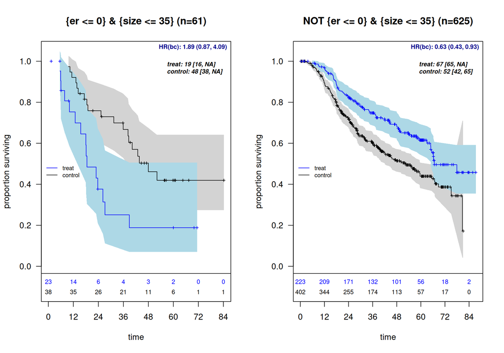

Kaplan-Meier survival curves by identified subgroup

```r
km_result <- plot_sg_weighted_km(
  fs.est = fs,
  outcome.name = "time_months",
  event.name = "status",
  treat.name = "hormon",
  show.logrank = FALSE,
  conf.int = TRUE,
  by.risk = 12,
  show.cox = FALSE, show.cox.bc = TRUE,
  fs_bc = fs_bc,
  hr_bc_position = "topright"
)
```

**Note**

**Note:** Identified subgroup: {er <= 0} & {size <= 35}. HR(bc) = bootstrap bias-corrected hazard ratio. Medians [95% CI] for arms are un-adjusted.

### 7.4.1 Event Count Summary

Low event counts can lead to unstable HR estimates. This summary helps identify potential issues:

```r
event_summary <- summarize_bootstrap_events(fs_bc, threshold = 10)
```

```
#>
#> === Bootstrap Event Count Summary ===
#> Total bootstrap iterations: 1000
#> Event threshold: <10 events
#>
#> ORIGINAL Subgroup H on BOOTSTRAP samples:
#>   Control arm <10 events: 0 (0.0%)
#>   Treatment arm <10 events: 0 (0.0%)
#>   Either arm <10 events: 0 (0.0%)
#>
#> ORIGINAL Subgroup Hc on BOOTSTRAP samples:
#>   Control arm <10 events: 0 (0.0%)
#>   Treatment arm <10 events: 0 (0.0%)
#>   Either arm <10 events: 0 (0.0%)
#>
#> NEW Subgroups found: 974 (97.4%)
#>
#> NEW Subgroup H* on ORIGINAL data:
#>   Control arm <10 events: 0 (0.0% of successful)
#>   Treatment arm <10 events: 0 (0.0% of successful)
#>   Either arm <10 events: 0 (0.0% of successful)
#>
#> NEW Subgroup Hc* on ORIGINAL data:
#>   Control arm <10 events: 0 (0.0% of successful)
#>   Treatment arm <10 events: 0 (0.0% of successful)
#>   Either arm <10 events: 0 (0.0% of successful)
```

### 7.4.2 Bootstrap Diagnostics

```r
# Quality metrics
summaries$diagnostics_table_gt
```

**Bootstrap Diagnostics Summary**

Analysis of 1000 bootstrap iterations

| Category | Metric | Value |
| --- | --- | --- |
| Success Rate | Total iterations | 1000 |
|  | Successful | 974 (97.4%) |
|  | Failed | 26 (2.6%) |
|  | Success rating | Excellent |
| Subgroup H (Questionable) | Observed HR | 2.537 |
|  | Bias-corrected HR | 1.889 |
|  | Bootstrap CV (%) | 77.6% |
|  | N estimates | 974 |
| Subgroup Hc (Recommend) | Observed HR | 0.608 |
|  | Bias-corrected HR | 0.632 |
|  | Bootstrap CV (%) | 48.2% |
|  | N estimates | 974 |

### 7.4.3 Subgroup Agreement

How consistently does bootstrap identify the same subgroup?

```r
# Agreement with original analysis
if (!is.null(summaries$subgroup_summary$original_agreement)) {
  summaries$subgroup_summary$original_agreement
}
```

```
#>                             Metric                    Value
#>                             <char>                   <char>
#> 1:      Total bootstrap iterations                     1000
#> 2:           Successful iterations                      974
#> 3: Failed iterations (no subgroup)                       26
#> 4:
#> 5:    Original subgroup definition {er <= 0} & {size <= 35}
#> 6:       Exact match with original                96 (9.9%)
#> 7:         Different from original              878 (90.1%)
#> 8:   Partial match (shared factor)              436 (44.8%)
```

```r
# Factor presence across bootstrap iterations
if (!is.null(summaries$subgroup_summary$factor_presence)) {
  summaries$subgroup_summary$factor_presence
}
```

```
#>   Rank Factor Count   Percent
#> 2    1     er   630 64.681725
#> 6    2    pgr   392 40.246407
#> 1    3    age   379 38.911704
#> 7    4   size   254 26.078029
#> 5    5  nodes   150 15.400411
#> 3    6 grade3    76  7.802875
#> 4    7   meno    39  4.004107
```

### 7.4.4 GRF-Cut Stability Across Bootstraps

Separately from whether bootstrap identifies the *same subgroup*, we can ask what raw cut GRF itself surfaced on each resample, independent of whether the downstream consistency stage accepted it. A dominant row here paired with a low `(no GRF cut)` rate indicates that GRF’s upstream discovery is stable across resamples; a frequent `(no GRF cut)` row indicates GRF itself is the source of variability. This distinction matters because the two failure modes call for different tuning responses — relaxing `dmin.grf` / `frac.tau` (for “GRF produced no cut”) vs. relaxing `pconsistency.threshold` (for “GRF produced a cut that consistency rejected”).

```r
if (!is.null(summaries$subgroup_summary$grf_cut_freq)) {
  summaries$subgroup_summary$grf_cut_freq |>
    utils::head(10) |>
    gt::gt() |>
    gt::tab_header(
      title = gt::md("**GRF cuts across bootstrap iterations**"),
      subtitle = "Top 10 by frequency; spans all bootstraps (not just successful ones)"
    ) |>
    gt::cols_label(
      Rank    = "Rank",
      grf_cut = "GRF cuts",
      N       = "N",
      Percent = "% of bootstraps"
    ) |>
    gt::fmt_number(columns = "Percent", decimals = 2) |>
    gt::tab_options(table.font.size = gt::px(13))
}
```

**GRF cuts across bootstrap iterations**

Top 10 by frequency; spans all bootstraps (not just successful ones)

| Rank | GRF cuts | N | % of bootstraps |
| --- | --- | --- | --- |
| 1 | er <= 0 | 269 | 26.90 |
| 2 | age <= 50 \| age <= 43 \| er <= 0 | 18 | 1.80 |
| 3 | (no GRF cut) | 16 | 1.60 |
| 4 | age <= 47 \| age <= 43 \| er <= 0 | 15 | 1.50 |
| 5 | age <= 48 \| age <= 43 \| er <= 0 | 14 | 1.40 |
| 6 | age <= 48 \| age <= 44 \| er <= 0 | 9 | 0.90 |
| 7 | age <= 50 \| age <= 44 \| er <= 0 | 9 | 0.90 |
| 8 | er <= 103 \| er <= 0 \| pgr <= 74 | 8 | 0.80 |
| 9 | age <= 47 \| age <= 44 \| er <= 0 | 7 | 0.70 |
| 10 | age <= 50 \| age <= 45 \| er <= 0 | 7 | 0.70 |

### 7.4.5 Bootstrap Distributions

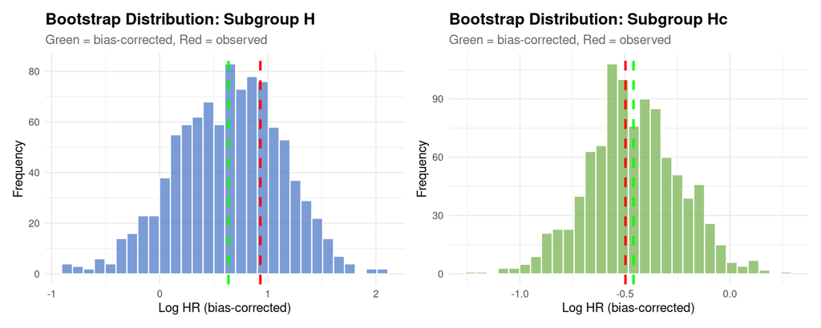

```r
if (!is.null(summaries$plots)) {
  summaries$plots$H_distribution + summaries$plots$Hc_distribution
}
```

# 8 Cross-Validation

Cross-validation assesses the **stability** of the ForestSearch algorithm. Two approaches are available:

## 8.1 K-Fold Cross-Validation

```r
cat("> **K-fold CV skipped.** Set `run_cv_kfold <- TRUE` in the Analysis Configuration to enable. The forest plot below will omit kfold CV metrics.\n")
```

```r
t0 <- proc.time()

fs_kfold <- forestsearch_tenfold(
  fs.est = fs,
  sims = Ksims,
  Kfolds = 10,
  details = FALSE,
  parallel_args = list(
    plan = "multisession",
    workers = n_cores,
    show_message = FALSE
  )
)

plan("sequential")
timings$kfold <- (proc.time() - t0)["elapsed"]
metrics_tables <- cv_metrics_tables(fs_kfold)
metrics_tables
```

**Cross-Validation Metrics**

Subgroup: Identified Subgroup

| Metric | Description | Value (%) |
| --- | --- | --- |
| Agreement |  |  |
| Sensitivity (H) | Agreement rate for subgroup H | 74.6 |
| Sensitivity (Hc) | Agreement rate for complement Hc | 95.1 |
| PPV (H) | Positive predictive value for H | 58.8 |
| PPV (Hc) | Positive predictive value for Hc | 97.5 |
| Subgroup Finding |  |  |
| Any Found | Any subgroup identified | 100.0 |
| Exact Match | Exact match on all factors | 0.0 |
| At Least 1 | At least one factor matches | 80.0 |
| Cov1 Any | First covariate found (any cut) | 80.0 |
| Cov2 Any | Second covariate found (any cut) | 0.0 |
| Cov1 & Cov2 | Both covariates found | 0.0 |
| Cov1 Exact | First covariate exact match | 80.0 |
| Cov2 Exact | Second covariate exact match | 0.0 |

Based on 50 simulation(s) with 10-fold CV. Values are medians shown as percentages.

### 8.1.1 Diagnostic Tabulations

`summarize_cv_results()` consolidates the per-fold record into a panel of diagnostic tables that together answer the core questions an analyst asks of a repeated K-fold run: which subgroups did the pipeline identify across resamples, which GRF cuts drove those identifications, when identification failed what was the proximate cause, and how confidently were the successful identifications made.

```r
cv_diag <- summarize_cv_results(
  cv_output         = fs_kfold,
  original_sg       = fs$sg.harm,
  original_grf_cuts = fs$grf_cuts,
  top_n             = 10L
)
```

**Which subgroups emerged across resamples?** The identification summary shows the distribution of selected subgroups across all 50 × 10 = 500 sim × fold pairs. A single dominant subgroup with high share indicates the pipeline converges on a stable selection; a long tail suggests selection is sensitive to the particular training split.

```r
cv_diag$identification_summary
```

**Identified subgroups across sim x fold pairs**

50 simulations x 10 folds = 500 total pairs

| Rank | Identified subgroup | n folds | % folds |
| --- | --- | --- | --- |
| 1 | {er <= 0} & {pgr <= 26} | 238 | 47.60 |
| 2 | {er <= 0} & {pgr <= 27} | 46 | 9.20 |
| 3 | !{age <= 43} & {age <= 47} | 33 | 6.60 |
| 4 | {er <= 0} | 26 | 5.20 |
| 5 | {er <= 0} & !{age <= 43} | 22 | 4.40 |
| 6 | {er <= 0} & {pgr <= 8} | 22 | 4.40 |
| 7 | (no subgroup) | 21 | 4.20 |
| 8 | {er <= 0} & {pgr <= 25} | 18 | 3.60 |
| 9 | {age <= 47} & !{age <= 43} | 16 | 3.20 |
| 10 | {er <= 0} & {pgr <= 16} | 6 | 1.20 |
| 11 | (35 others) | 52 | 10.40 |

**Which GRF cuts drove those selections?** The GRF cut summary tabulates the raw policy-tree output on each training fold, independent of whether the downstream consistency stage accepted it. Comparison against the identification summary reveals whether GRF’s upstream discovery is stable (a dominant cut shared across folds) or noisy (a long tail of one-off cuts).

```r
cv_diag$grf_cut_summary
```

**GRF cuts across training sets**

Raw grf_cuts strings; 50 simulations x 10 folds = 500 total pairs

| Rank | GRF cuts | n folds | % folds |
| --- | --- | --- | --- |
| 1 | er <= 0 | 223 | 44.60 |
| 2 | age <= 48 \| age <= 43 \| er <= 0 | 84 | 16.80 |
| 3 | age <= 47 \| age <= 43 \| er <= 0 | 70 | 14.00 |
| 4 | age <= 50 \| age <= 43 \| er <= 0 | 52 | 10.40 |
| 5 | age <= 48 \| age <= 44 \| er <= 0 | 12 | 2.40 |
| 6 | age <= 50 \| age <= 44 \| er <= 0 | 9 | 1.80 |
| 7 | age <= 47 \| age <= 44 \| er <= 0 | 7 | 1.40 |
| 8 | age <= 48 \| age <= 45 \| er <= 0 | 5 | 1.00 |
| 9 | age <= 47 \| age <= 42 \| er <= 0 | 3 | 0.60 |
| 10 | age <= 47 \| age <= 43 \| er <= 369 | 3 | 0.60 |
| 11 | (25 others) | 32 | 6.40 |

**When a fold failed to identify a subgroup, why?** The no-subgroup decomposition splits the non-identifying folds into two actionable buckets: *GRF returned no cut* (nothing for consistency to evaluate, typically pointing at `dmin.grf` or `frac.tau` thresholds) versus *GRF returned a cut but consistency rejected it* (candidates existed but none met `pconsistency.threshold`). The former argues for relaxing the GRF upstream; the latter for relaxing the consistency threshold or reviewing candidate quality.

```r
cv_diag$no_subgroup_decomposition
```

**Decomposition of no-subgroup folds**

Out of 500 sim x fold pairs

| Category | n folds | % of all pairs | % of no-sg folds |
| --- | --- | --- | --- |
| Folds with no subgroup identified | 21 | 4.20 | 100.00 |
| GRF returned no cut | 0 | 0.00 | 0.00 |
| GRF returned a cut; consistency rejected | 21 | 4.20 | 100.00 |

Guidance: a high 'GRF returned no cut' share argues for relaxing dmin.grf; a high 'consistency rejected' share argues for relaxing pconsistency.threshold.

**How confidently were the successful identifications made?** Among folds that *did* identify a subgroup, the `pconsistency_distribution` shows where the selected candidate’s consistency probability (`Pcons`) landed relative to the 0.90 threshold. Identifications in the `[0.85, 0.95)` bin are marginal; those concentrated at or near 1.0 are robust.

```r
cv_diag$pconsistency_distribution
```

**Pcons distribution among identifying folds**

Out of 500 sim x fold pairs

| Pcons range | n folds | % of identifying folds |
| --- | --- | --- |
| <0.5 | 0 | 0.00 |
| 0.5-0.7 | 0 | 0.00 |
| 0.7-0.8 | 0 | 0.00 |
| 0.8-0.85 | 0 | 0.00 |
| 0.85-0.95 | 47 | 9.81 |
| >=0.95 | 432 | 90.19 |
| Median (identifying): 0.970 | – | – |
| IQR (identifying): 0.960 - 1.000 | – | – |
| Identifying folds total | 479 | 95.80 |

Restricted to folds that identified a subgroup. A concentration near the pconsistency.threshold (typically 0.90) suggests many identifications are marginal; concentration above 0.95 suggests robust identifications. Values for rejected candidates are not surfaced -- only the selected candidate's Pcons is captured.

**How do all the numeric fold-level diagnostics summarize together?** The `fold_numeric_summary` tabulates median / IQR / range for each numeric column in the per-fold record: fold size (`n_test`), consistency probability (`pconsistency`), training-fold HR of the selected subgroup (`training_fs_hr`, optimistically biased — for diagnostic comparison only), and candidate count (`n_candidates_evaluated`).

```r
cv_diag$fold_numeric_summary
```

**Fold-level numeric diagnostics**

Across 500 sim x fold pairs; per-metric denominator shown in Context

| Metric | n | Median | Q1 | Q3 | Min | Max | n NA | Context |
| --- | --- | --- | --- | --- | --- | --- | --- | --- |
| Test-fold size (n_test) | 500 | 69.000 | 68.000 | 69.000 | 68.000 | 69.000 | 0 | All sim x fold pairs |
| Pcons (identifying folds) | 479 | 0.970 | 0.960 | 1.000 | 0.900 | 1.000 | 21 | Folds that identified a subgroup |
| Training-fold subgroup effect (identifying folds) | 479 | 2.244 | 2.091 | 2.461 | 1.507 | 3.703 | 21 | Natural scale; in-sample; optimistically biased |
| Candidates evaluated per fold | 500 | 1.000 | 1.000 | 1.000 | 1.000 | 20.000 | 0 | Folds where consistency stage ran |

Training-fold subgroup effects are in-sample estimates on the effect measure's natural scale (HR for survival; OR, RR, IRR, RD, IRD, or MD for GLM). They are optimistically biased and shown here for diagnostic comparison across folds only; do not use for inference.

**Agreement with the full-data analysis.** How often does a training fold reproduce the original full-data subgroup exactly, share a factor with it, or match its GRF cut?

```r
cv_diag$original_agreement
```

**Agreement with original full-data analysis**

Fraction of sim x fold pairs matching the original result

|  | Value |
| --- | --- |
| Total sim x fold pairs | 500 |
| Original subgroup definition | {er <= 0} & {size <= 35} |
| Exact subgroup match | 0 (0.0%) |
| Partial match (>=1 shared factor) | 397 (79.4%) |
| Original GRF cut(s) | er <= 0 |
| Exact GRF-cut match | 223 (44.6%) |
| Both subgroup and GRF cut match | 0 (0.0%) |

## 8.2 Out-of-Bag (N-Fold) Cross-Validation

N-fold CV (leave-one-out):

```r
cat("> **OOB (leave-one-out) CV skipped.** Set `run_cv_oob <- TRUE` in the Analysis Configuration to enable. This is the most expensive component of the document (~20-30 min on GBSG).\n")
```

```r
t0 <- proc.time()

fs_OOB <- forestsearch_Kfold(
  fs.est = fs,
  details = FALSE,
  Kfolds = nrow(df.analysis),  # N-fold = leave-one-out
  parallel_args = list(
    plan = "multisession",
    workers = n_cores,
    show_message = TRUE
  )
)
```

```
#> Parallel plan: multisession with 30 workers.
```

```r
plan("sequential")
timings$oob <- (proc.time() - t0)["elapsed"]

# Summarize OOB results
cv_out <- forestsearch_KfoldOut(
  res = fs_OOB,
  details = FALSE,
  outall = TRUE
)

tables <- cv_summary_tables(cv_out)

tables$combined_table
```

**Cross-Validation Summary**

ITT and Subgroup Estimates: Full Analysis (FA) vs K-fold (Kf)

| Analysis | Subgroup | n | n1 | m1 | m0 | RMST | Hazard ratio |
| --- | --- | --- | --- | --- | --- | --- | --- |
| Overall | ITT | 686 (100.0%) | 246 (35.9%) | 66.3 | 50.2 | 7.8 | 0.69 (0.54, 0.89) |
| FA_0 | Not recommend | 61 (8.9%) | 23 (37.7%) | 18.5 | 48 | -19 | 2.54 (1.25, 5.17) |
| KfA_0 | Not recommend | 42 (6.1%) | 14 (33.3%) | 23.3 | 52.1 | -18 | 2.69 (1.09, 6.68) |
| FA_1 | Recommend | 625 (91.1%) | 223 (35.7%) | 66.7 | 52.2 | 9.6 | 0.61 (0.47, 0.79) |
| KfA_1 | Recommend | 644 (93.9%) | 232 (36.0%) | 66.7 | 50.2 | 8.8 | 0.64 (0.50, 0.82) |

FA = Full Analysis (original data), Kf = K-fold CV estimate

```r
tables$metrics_table
```

**Cross-Validation Metrics**

Agreement and subgroup finding rates (%)

| Metric | Value (%) |
| --- | --- |
| Agreement |  |
| Sensitivity (H) | 68.852 |
| Sensitivity (Hc) | 100.000 |
| PPV (H) | 100.000 |
| PPV (Hc) | 97.050 |
| Finding |  |
| Any Found | 100.000 |
| Exact Match | 91.108 |
| At Least 1 | 100.000 |
| Cov1 Any | 100.000 |
| Cov2 Any | 91.108 |
| Cov1 & Cov2 | 91.108 |
| Cov1 Exact | 100.000 |
| Cov2 Exact | 91.108 |

# 9 Results Visualization

## 9.1 Forest Plot

The forest plot summarizes treatment effects across the ITT population, reference subgroups, and identified subgroups with cross-validation metrics.

```r
# Define reference subgroups for comparison
subgroups <- list(
  age_gt65 = list(
    subset_expr = "age > 65",
    name = "Age > 65",
    type = "reference"
  ),
  age_le65 = list(
    subset_expr = "age <= 65",
    name = "Age <= 65",
    type = "reference"
  ),
  pgr_positive = list(
    subset_expr = "pgr > 0",
    name = "PgR > 0",
    type = "reference"
  ),
  pgr_negative = list(
    subset_expr = "pgr <= 0",
    name = "PgR <= 0",
    type = "reference"
  )
)


my_theme <- create_forest_theme(base_size = 24,
  footnote_fontsize = 17, cv_fontsize = 22)


# Create forest plot.  fs_kfold / fs_OOB enter only when the
# corresponding CV step ran; otherwise NULL omits them from the
# plot's CV metrics columns.
result <- plot_subgroup_results_forestplot(
  fs_results = list(
    fs.est   = fs,
    fs_bc    = fs_bc,
    fs_OOB   = if (run_cv_oob)   fs_OOB   else NULL,
    fs_kfold = if (run_cv_kfold) fs_kfold else NULL
  ),
  df_analysis = df.analysis,
  subgroup_list = subgroups,
  outcome.name = outcome.name,
  event.name = event.name,
  treat.name = treat.name,
  E.name = "Hormonal",
  C.name = "Chemo",
  ci_column_spaces = 25,
  xlog = TRUE,
  theme = my_theme
)
```

```
#> refline_lwd, refline_lty, refline_col will be deprecated, use refline_gp instead.
```

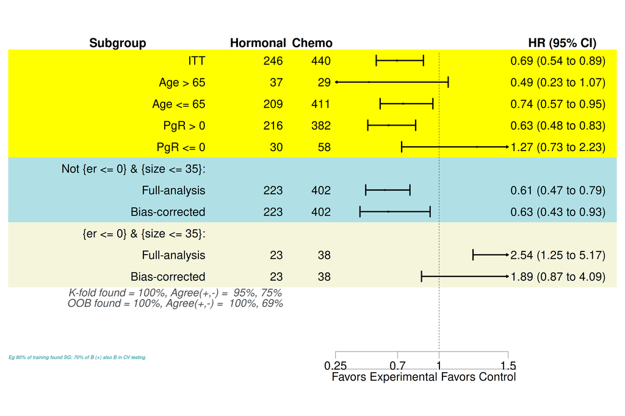

Subgroup forest plot including identified subgroups

```r
# Render forest plot
render_forestplot(result)
```

### 9.1.1 KM Difference Plots: ITT and Subgroups

The solid black line denotes the ITT Kaplan-Meier treatment difference estimates along with 95% CIs (the grey shaded region). K-M differences corresponding to subgroups are displayed.

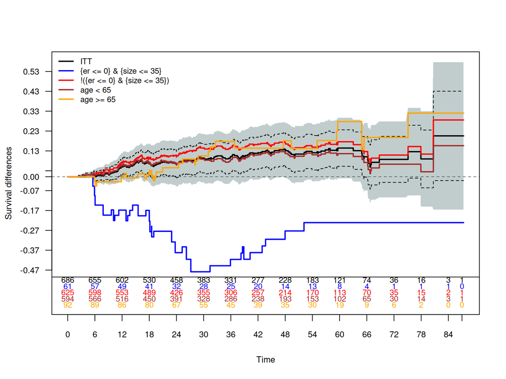

```r
# Add additional subgroups along with ITT and identified subgroups
ref_sgs <- list(
  age_young = list(subset_expr = "age < 65", color = "brown"),
  age_old = list(subset_expr = "age >= 65", color = "orange")
)

plot_km_band_forestsearch(
  df = df.analysis,
  fs.est = fs,
  ref_subgroups = ref_sgs,
  outcome.name = outcome.name,
  event.name = event.name,
  treat.name = treat.name,
  draws_band = 20
)
```

# 10 Summary and Interpretation

## 10.1 Key Findings

```r
cat(strrep("=", 60), "\n")
cat("FORESTSEARCH ANALYSIS SUMMARY\n")
```

```
#> FORESTSEARCH ANALYSIS SUMMARY
```

```r
cat(strrep("=", 60), "\n\n")
cat("Dataset: GBSG (N =", nrow(df.analysis), ")\n")
```

```
#> Dataset: GBSG (N = 686 )
```

```r
cat("Outcome: Recurrence-free survival\n\n")
```

```
#> Outcome: Recurrence-free survival
```

```r
cat("ITT Analysis:\n")
```

```
#> ITT Analysis:
```

```r
cat("  HR (95% CI): 0.69 (0.54, 0.89)\n\n")
```

```
#>   HR (95% CI): 0.69 (0.54, 0.89)
```

```r
cat("Identified Subgroup (H):\n")
```

```
#> Identified Subgroup (H):
```

```r
cat("  Definition:", paste(fs$sg.harm, collapse = " & "), "\n")
```

```
#>   Definition: {er <= 0} & {size <= 35}
```

```r
cat("  Size:", sum(fs$df.est$treat.recommend == 0),
    sprintf("(%.1f%%)\n", 100 * mean(fs$df.est$treat.recommend == 0)))
```

```
#>   Size: 61 (8.9%)
```

```r
cat("  Unadjusted HR:",
    sprintf("%.2f", exp(fs$grp.consistency$out_sg$result$hr[1])), "\n")
```

[output not shown]

```r
cat("\nComplement Subgroup (Hc):\n")
```

```
#>
#> Complement Subgroup (Hc):
```

```r
cat("  Size:", sum(fs$df.est$treat.recommend == 1),
    sprintf("(%.1f%%)\n", 100 * mean(fs$df.est$treat.recommend == 1)))
```

```
#>   Size: 625 (91.1%)
```

## 10.2 Clinical Interpretation

**Biological plausibility**: Tamoxifen is a selective estrogen receptor modulator. Its efficacy depends on ER expression. The finding that ER-negative patients may not benefit is consistent with:

- Mechanistic understanding of tamoxifen action
- Meta-analyses showing no tamoxifen benefit in ER-negative breast cancer
- Clinical guidelines recommending tamoxifen primarily for ER-positive tumors

**Caveats**:

1. This is an **exploratory** analysis requiring independent validation
2. The bias-corrected estimates have wider confidence intervals
3. Cross-validation metrics should be evaluated for algorithm stability

## 10.3 Computational Timing

```r
timings$total <- (proc.time() - t_vignette_start)["elapsed"]

timing_df <- data.frame(
  Analysis = c("GRF", "ForestSearch", "Bootstrap", "kfold", "oob", "Total"),
  Seconds = c(
    timings$grf,
    timings$forestsearch,
    timings$bootstrap,
    timings$kfold,
    timings$oob,
    timings$total
  )
)
timing_df$Minutes <- timing_df$Seconds / 60

gt(timing_df) |>
  tab_header(title = "Computational Timing") |>
  fmt_number(columns = c(Seconds, Minutes), decimals = 1) |>
  cols_label(
    Analysis = "Component",
    Seconds = "Time (sec)",
    Minutes = "Time (min)"
  )
```

Computational Timing

| Component | Time (sec) | Time (min) |
| --- | --- | --- |
| GRF | 0.4 | 0.0 |
| ForestSearch | 6.5 | 0.1 |
| Bootstrap | 844.6 | 14.1 |
| kfold | 423.3 | 7.1 |
| oob | 481.7 | 8.0 |
| Total | 1,762.0 | 29.4 |

# 11 References

León LF, Jemielita T, Guo Z, Marceau West R, Anderson KM (2024). “Exploratory subgroup identification in the heterogeneous Cox model: A relatively simple procedure.” *Statistics in Medicine*. DOI: 10.1002/sim.10163